# Stat 615 Final_Project

Dhruv Jain & mekdim

2023-04-20

## ACKNOWLEDGEMENTS

“I am not what happened to me, I am what I choose to become” by Christopher Gardner, The Pursuit of Happiness.

It is always a pleasure to remember the fine people who guided us in the Regression program. We received to uphold our practical and theoretical skills during the respective session. Firstly, we would like to thank **Pro. James C. Dickens** and secondly, we want to thank our family & friends for their love, motivation, and support during this semester in American university. Thanks for all the ideas, opinions, knowledge, and suggestions given to us to help us complete this report. We are very thankful to American University for giving us the opportunity to pursue this project.

# Title Page with Executive Summary

**Title:** Estimating Medical Cost via random forest.

**Type of analysis:** Application analysis

**Table 1:**

| Name | course |
| --- | --- |
| Dhruv Jain | STAT -615 |
| Mekdim Ashebo | STAT -615 |

```r
# calling all the libraries used in the code book
# Install this for latex pdf output.
#tinytex::install_tinytex()
library(olsrr)
library(tidyverse)
library(dbplyr)
library(dplyr)
library(Matrix)
library(MASS)
library(ggplot2)
library(tibble)
library(data.table)
library(ggmosaic)
library(ggforce)
library(ggmap)
library(ggthemes)
library(purrr)
library(keep)
library(readr)
library(gridExtra)
library(randomForest)
library(corrplot)
library(PerformanceAnalytics)
```

# 1 All About Data Set

## 1.1 Data Set Source

**Data source**: **website name**:Kaggle. [Website link](https://www.kaggle.com/datasets/mirichoi0218/insurance)

**Overall approach** is Cleaning, analyzing, again cleaning, answering the five questions, playing with data to deliver more better output and finally graphical representation. **Defining** the issues and trying to resolve that by presenting the medical cost data set . **Measure** overall what can be done. **Analyze** the data to use for future capability. **Improving** You will use information gathered in the previous phases to design and implement improvements in processing with consistency. Overall Approach to this question is using various tools and coding sets with providing the statistical data with convincing evidence.

Clean –> Design –> Plot –-> Types Regression model –> hypothesis –> statistical findings –> Random forest –> conclusion

**Recommendations:** Using R-studio markdown one can achieve high graphical results with better quality and one can also conclude that big data can be easily handled on this platform. Using this platform, we will continue to evaluate the medical cost for personal data using this tool. The issue is that what can be done with the data can we provided some explanation to justify the results. We would like to address those five questions with different visual ideas.

**IMPORTANT KEYWORDS:**

- charges
- Smoker
- sex
- BMI (body mass index)
- P-value
- Random forest

**Columns Description**

**age**: age of primary beneficiary **sex**: insurance contractor gender, female, male **bmi** Body mass index, providing an understanding of body, weights that are relatively high or low relative to height, objective index of body weight (kg / m ^ 2) using the ratio of height to weight, ideally 18.5 to 24.9. **children**: Number of children covered by health insurance / Number of dependents **smoker**: Smoking **region**: the beneficiary’s residential area in the US, northeast, southeast, southwest, northwest. **charges**: Individual medical costs billed by health insurance

We had to randomly sample 300 rows from our original data. We then saved these 300 rows into csv file so that we can import them later. going forward We will take that csv file. (which has only be run once)

```r
# The preliminary steps we did
#insurance <- read_csv('Downloads/insurance.csv')
#insurance_300 <- sample_n(insurance, 300)
#write.csv(insurance_300 , file = "Desktop/insurance_300.csv")
```

```r
insurance_new <- read_csv("insurance_300.csv",
col_types = cols(
  age = col_double(),
  sex = col_character(),
  bmi = col_double(),
  children = col_double(),
  smoker = col_character(),
  region = col_character(),
  charges = col_double()
))
```

- The data contains 300 rows and 7 columns. This project is about determining the factors that affect medical costs billed by health insurance.
- The independent variables include three categorical variables and three quantitative variables.Sex (male/female), region(Northeast, northwest etc), and smoker(whether a person smokes or not) are the categorical variables. While the quantitative variables include the BMI index, the age and the number of children the person have.

```r
head(insurance_new,8)
```

```
## # A tibble: 8 × 7
##     age sex      bmi children smoker region    charges
##   <dbl> <chr>  <dbl>    <dbl> <chr>  <chr>       <dbl>
## 1    63 female  25.1        0 no     northwest  14255.
## 2    18 male    38.2        0 yes    southeast  36308.
## 3    48 male    29.6        0 no     southwest  21232.
## 4    46 female  33.4        1 no     southeast   8241.
## 5    52 male    30.2        1 no     southwest   9725.
## 6    36 female  19.9        0 no     northeast   5458.
## 7    19 male    20.9        1 no     southwest   1832.
## 8    48 male    36.7        1 no     northwest  28469.
```

```r
nrow(insurance_new)
```

```
## [1] 300
```

```r
ncol(insurance_new)
```

```
## [1] 7
```

```r
colnames(insurance_new)
```

```
## [1] "age"      "sex"      "bmi"      "children" "smoker"   "region"   "charges"
```

- Let us quickly investigate the summary of our dependent variable. The median insurance charge is around 10097 and the mean of 13283. The standard deviation is 11399.

```r
summary(insurance_new)
```

```
##       age            sex                 bmi           children
##  Min.   :18.00   Length:300         Min.   :17.29   Min.   :0.00
##  1st Qu.:27.00   Class :character   1st Qu.:25.25   1st Qu.:0.00
##  Median :40.50   Mode  :character   Median :30.01   Median :1.00
##  Mean   :39.88                      Mean   :30.02   Mean   :1.02
##  3rd Qu.:53.00                      3rd Qu.:34.20   3rd Qu.:2.00
##  Max.   :64.00                      Max.   :46.75   Max.   :5.00
##     smoker             region             charges
##  Length:300         Length:300         Min.   : 1136
##  Class :character   Class :character   1st Qu.: 5134
##  Mode  :character   Mode  :character   Median :10097
##                                        Mean   :13283
##                                        3rd Qu.:17154
##                                        Max.   :51195
```

- Type of columns used in data frame (double, charterer)

```r
str(insurance_new)
```

```
## spc_tbl_ [300 × 7] (S3: spec_tbl_df/tbl_df/tbl/data.frame)
##  $ age     : num [1:300] 63 18 48 46 52 36 19 48 19 19 ...
##  $ sex     : chr [1:300] "female" "male" "male" "female" ...
##  $ bmi     : num [1:300] 25.1 38.2 29.6 33.4 30.2 ...
##  $ children: num [1:300] 0 0 0 1 1 0 1 1 0 0 ...
##  $ smoker  : chr [1:300] "no" "yes" "no" "no" ...
##  $ region  : chr [1:300] "northwest" "southeast" "southwest" "southeast" ...
##  $ charges : num [1:300] 14255 36308 21232 8241 9725 ...
##  - attr(*, "spec")=
##   .. cols(
##   ..   age = col_double(),
##   ..   sex = col_character(),
##   ..   bmi = col_double(),
##   ..   children = col_double(),
##   ..   smoker = col_character(),
##   ..   region = col_character(),
##   ..   charges = col_double()
##   .. )
##  - attr(*, "problems")=<externalptr>
```

## 1.2 Cleaning the data and type of columns

```r
# calculating NA/missing data in columns
colSums(is.na(insurance_new))
```

```
##      age      sex      bmi children   smoker   region  charges
##        0        0        0        0        0        0        0
```

```r
# converting to factor variable
insurance_new$sex = as.factor(insurance_new$sex)
insurance_new$smoker = as.factor(insurance_new$smoker)
# how many unique values
unique(insurance_new$sex)
```

```
## [1] female male
## Levels: female male
```

```r
unique(insurance_new$children)
```

```
## [1] 0 1 2 5 3 4
```

```r
unique(insurance_new$smoker)
```

```
## [1] no  yes
## Levels: no yes
```

```r
unique(insurance_new$region)
```

```
## [1] "northwest" "southeast" "southwest" "northeast"
```

```r
# Check levels of smoker variable
table(insurance_new$smoker)
```

```
##
##  no yes
## 239  61
```

```r
# Check levels of region variable
table(insurance_new$region)
```

```
##
## northeast northwest southeast southwest
##        67        77        76        80
```

```r
# Check levels of sex variable
table(insurance_new$sex)
```

```
##
## female   male
##    134    166
```

## 1.3 Visualization

### 1.3.a Does age affect medical charges for smoker?

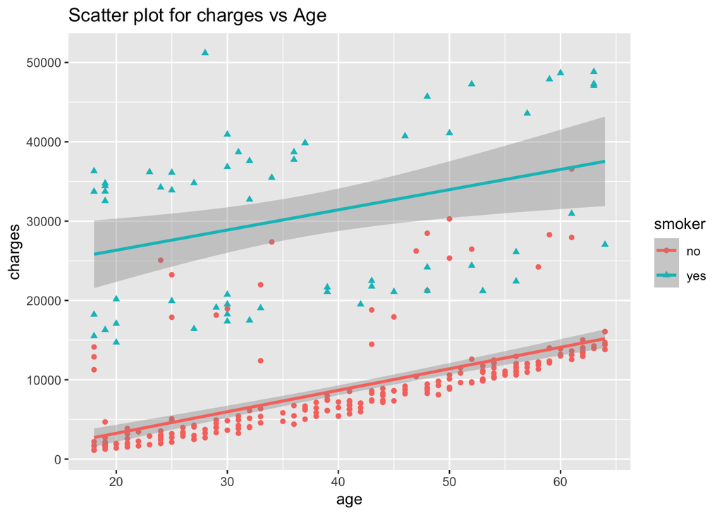

Scatter plot for charges vs Age

- Yes the charges are increased as we increase the number of age. Now the fun part is if a person smokes he/she is paying more charges on medical then the person not smoking.

### 1.3.b Does Body mass index (BMI) affect medical charges for smoker?

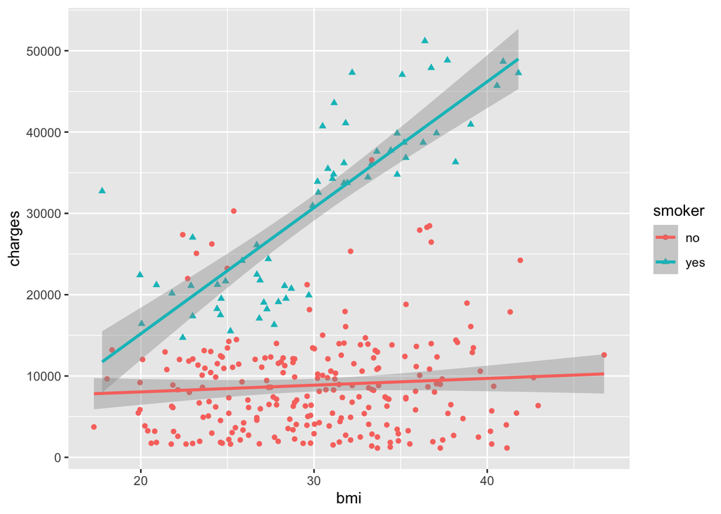

- One can clearly observe that smoking affect in BMI and increased with the medical expenses.

### 1.3.c Histogram for density graph for Body mass index (BMI)

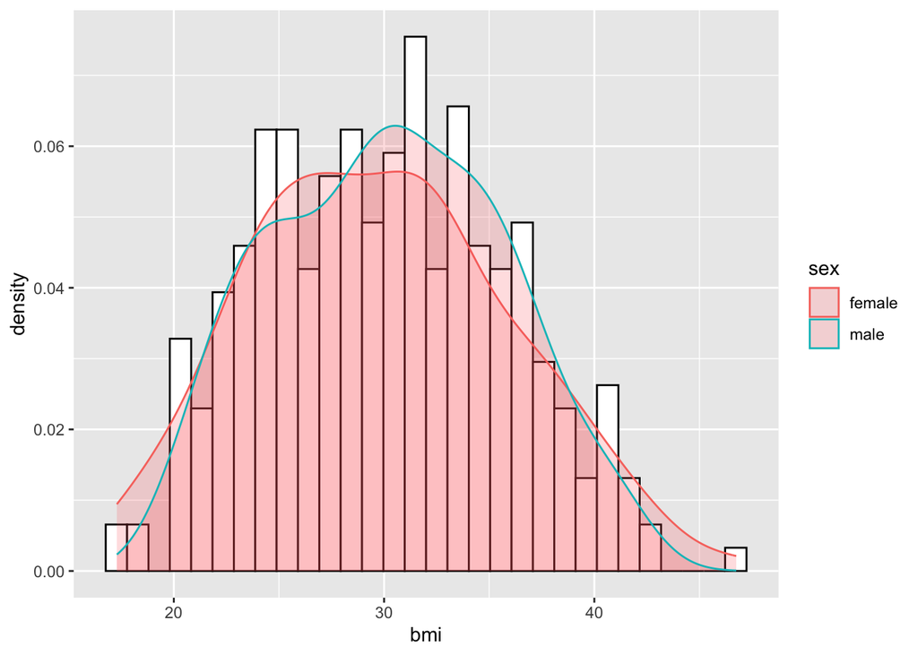

- The graph is density vs body mass index for male and female counts in the data set.

### 1.3.d High no. of smokers from which region ?

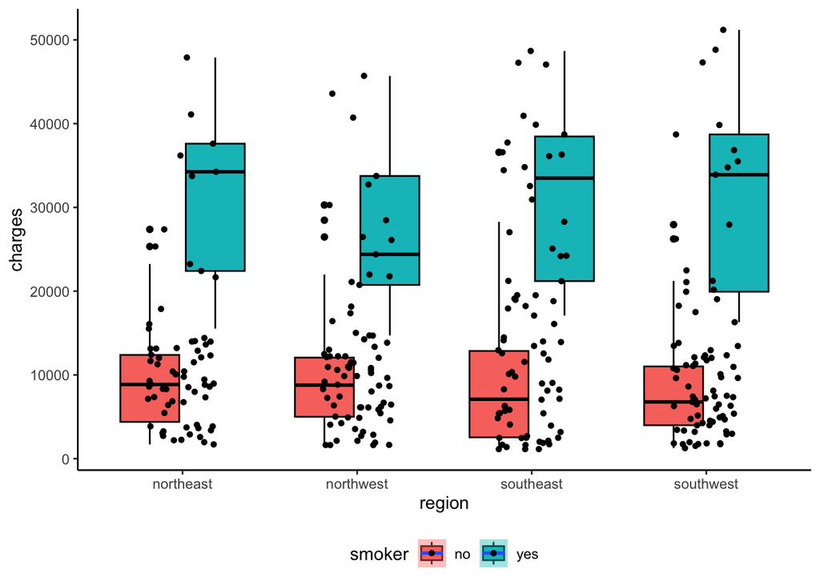

- comparing that does region of living affects the smokers or not. Now, looking at graph one cans say that the region does affect the charges on medical insurance.

### 1.3.e

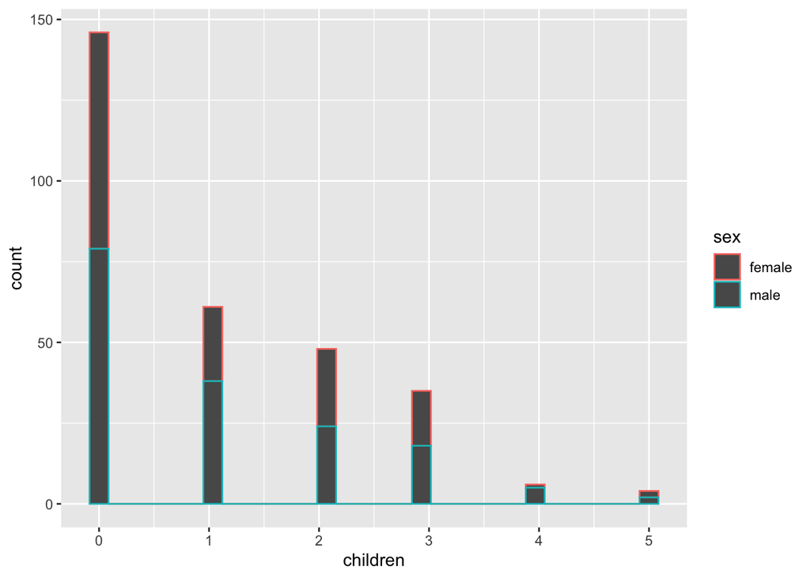

## 1.4 No. of counts

```r
# Female
insurance_new%>%
  filter(sex == "female")%>%
  count(sex,children,smoker,region)%>%
  arrange(sex, smoker) -> counts

head(counts,n=5)
```

```
## # A tibble: 5 × 5
##   sex    children smoker region        n
##   <fct>     <dbl> <fct>  <chr>     <int>
## 1 female        0 no     northeast    14
## 2 female        0 no     northwest    17
## 3 female        0 no     southeast    14
## 4 female        0 no     southwest    13
## 5 female        1 no     northeast     5
```

```r
# Male
insurance_new%>%
  filter(sex == "male")%>%
  count(sex,children,smoker,region)%>%
  arrange(sex, smoker) -> counts_male

head(counts_male,n=5)
```

```
## # A tibble: 5 × 5
##   sex   children smoker region        n
##   <fct>    <dbl> <fct>  <chr>     <int>
## 1 male         0 no     northeast    17
## 2 male         0 no     northwest    15
## 3 male         0 no     southeast    14
## 4 male         0 no     southwest    14
## 5 male         1 no     northeast     6
```

# 2 QQ & Multicollinearity plot description

## 2.1 Multicollinearity plot

- The response variable is not dependent on explanatory variable interns of multicollinearity.
- The highest correlation is between charges and age with only 0.24. But if we exclude charges since charges is dependent variable, the highest correlation among the independent variables.
- The age with bmi with only 0.04 which is nearly 0. So there exists no colinearity among the independent variables. This suggests that each of the variables might be useful if they are included in the regression model as they dont have any correlation with each other.

```r
numeric_insurance <- cor(insurance_new[,c("bmi", "children", "age", "charges")])

numeric_insurance
```

```
##                  bmi    children        age   charges
## bmi       1.00000000 -0.01371482 0.04733455 0.1785191
## children -0.01371482  1.00000000 0.03529611 0.0781793
## age       0.04733455  0.03529611 1.00000000 0.2461625
## charges   0.17851911  0.07817930 0.24616249 1.0000000
```

[figure not shown]

multicollinearity plot